# Rose Project 2

## Problem Statement:

For this particular assignment, the data of different types of wine sales in the 20th century is to be analysed. Both of these data are from the same company but of different wines. As an analyst in the ABC Estate Wines, you are tasked to analyse and forecast Wine Sales in the 20th century

## Import the requred libraries

```python
import numpy as np
import pandas as pd
import seaborn as sns
from matplotlib import pyplot as plt
import warnings
warnings.filterwarnings('ignore', 'statsmodels.tsa.arima_model.ARMA',
                        FutureWarning)
warnings.filterwarnings('ignore', 'statsmodels.tsa.arima_model.ARIMA',
                        FutureWarning)
```

## 1. Read the data as an appropriate Time Series data and plot the data

### Reading the Dataset:

```python
df_1=pd.read_csv("Rose.csv")
```

### Checking the head and tail of Dataset:

```python
df_1.head()
```

|  | YearMonth | Rose |
| --- | --- | --- |
| 0 | 1980-01 | 112.0 |
| 1 | 1980-02 | 118.0 |
| 2 | 1980-03 | 129.0 |
| 3 | 1980-04 | 99.0 |
| 4 | 1980-05 | 116.0 |

```python
df_1.tail()
```

|  | YearMonth | Rose |
| --- | --- | --- |
| 182 | 1995-03 | 45.0 |
| 183 | 1995-04 | 52.0 |
| 184 | 1995-05 | 28.0 |
| 185 | 1995-06 | 40.0 |
| 186 | 1995-07 | 62.0 |

### Shape of Dataset:

```python
print('Number of rows:',df_1.shape[0])
print('Number of column:',df_1.shape[1])
```

```
Number of rows: 187
Number of column: 2
```

### Checking Info in Dataset:

```python
df_1.info()
```

```
<class 'pandas.core.frame.DataFrame'>
RangeIndex: 187 entries, 0 to 186
Data columns (total 2 columns):
 #   Column     Non-Null Count  Dtype
---  ------     --------------  -----
 0   YearMonth  187 non-null    object
 1   Rose       185 non-null    float64
dtypes: float64(1), object(1)
memory usage: 3.0+ KB
```

### Checking Null Values in Dataset:

```python
count1=df_1.isnull().sum().sum()
print('Number of null values in Dataset:',count1)
```

```
Number of null values in Dataset: 2
```

### Checking duplicates in dataset:

```python
dups=df_1.duplicated().sum()
print('number of duplicates:%d'%(dups))
```

```
number of duplicates:0
```

### Creating the Time Stamps and adding to the data frame to make it a Time Series Data:

```python
date = pd.date_range(start='1/1/1980', end='8/1/1995', freq='M')
date
```

```
DatetimeIndex(['1980-01-31', '1980-02-29', '1980-03-31', '1980-04-30',
               '1980-05-31', '1980-06-30', '1980-07-31', '1980-08-31',
               '1980-09-30', '1980-10-31',
               ...
               '1994-10-31', '1994-11-30', '1994-12-31', '1995-01-31',
               '1995-02-28', '1995-03-31', '1995-04-30', '1995-05-31',
               '1995-06-30', '1995-07-31'],
              dtype='datetime64[ns]', length=187, freq='M')
```

```python
df_1['Time_Stamp'] = pd.DataFrame(date,columns=['Month'])
df_1.head()
```

|  | YearMonth | Rose | Time_Stamp |
| --- | --- | --- | --- |
| 0 | 1980-01 | 112.0 | 1980-01-31 |
| 1 | 1980-02 | 118.0 | 1980-02-29 |
| 2 | 1980-03 | 129.0 | 1980-03-31 |
| 3 | 1980-04 | 99.0 | 1980-04-30 |
| 4 | 1980-05 | 116.0 | 1980-05-31 |

### Dropping Yearmonth Column:

```python
df_1['Time_Stamp'] = pd.to_datetime(df_1['Time_Stamp'])
```

```python
df_1.info()
```

```
<class 'pandas.core.frame.DataFrame'>
RangeIndex: 187 entries, 0 to 186
Data columns (total 3 columns):
 #   Column      Non-Null Count  Dtype
---  ------      --------------  -----
 0   YearMonth   187 non-null    object
 1   Rose        185 non-null    float64
 2   Time_Stamp  187 non-null    datetime64[ns]
dtypes: datetime64[ns](1), float64(1), object(1)
memory usage: 4.5+ KB
```

```python
df = df_1.set_index('Time_Stamp')
df.drop(['YearMonth'], axis=1, inplace=True)
df.head()
```

| Time_Stamp | Rose |
| --- | --- |
| 1980-01-31 | 112.0 |
| 1980-02-29 | 118.0 |
| 1980-03-31 | 129.0 |
| 1980-04-30 | 99.0 |
| 1980-05-31 | 116.0 |

```python
df['1994']
```

| Time_Stamp | Rose |
| --- | --- |
| 1994-01-31 | 30.0 |
| 1994-02-28 | 35.0 |
| 1994-03-31 | 42.0 |
| 1994-04-30 | 48.0 |
| 1994-05-31 | 44.0 |
| 1994-06-30 | 45.0 |
| 1994-07-31 | NaN |
| 1994-08-31 | NaN |
| 1994-09-30 | 46.0 |
| 1994-10-31 | 51.0 |
| 1994-11-30 | 63.0 |
| 1994-12-31 | 84.0 |

```python
df.interpolate(method='spline',order=2)['1994']
```

| Time_Stamp | Rose |
| --- | --- |
| 1994-01-31 | 30.000000 |
| 1994-02-28 | 35.000000 |
| 1994-03-31 | 42.000000 |
| 1994-04-30 | 48.000000 |
| 1994-05-31 | 44.000000 |
| 1994-06-30 | 45.000000 |
| 1994-07-31 | 45.386725 |
| 1994-08-31 | 44.635276 |
| 1994-09-30 | 46.000000 |
| 1994-10-31 | 51.000000 |
| 1994-11-30 | 63.000000 |
| 1994-12-31 | 84.000000 |

```python
df['1994']=df.interpolate(method='spline',order=2)['1994']
```

```python
count2=df.isnull().sum().sum()
print('Number of null values in Dataset:',count2)
```

```
Number of null values in Dataset: 0
```

### Plot the Time Series to understand the behaviour of the data

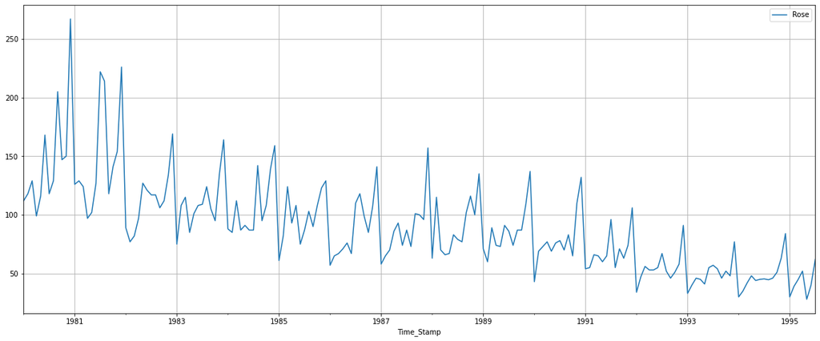

```python
df.plot(figsize=(20,8))
plt.grid();
```

### Check the basic measures of descriptive statistics of the Time Series:

```python
round(df_1.describe(),3)
```

|  | Rose |
| --- | --- |
| count | 185.000 |
| mean | 90.395 |
| std | 39.175 |
| min | 28.000 |
| 25% | 63.000 |
| 50% | 86.000 |
| 75% | 112.000 |
| max | 267.000 |

## 2. Perform appropriate Exploratory Data Analysis to understand the data and also perform decomposition

### Yearly Boxplot:

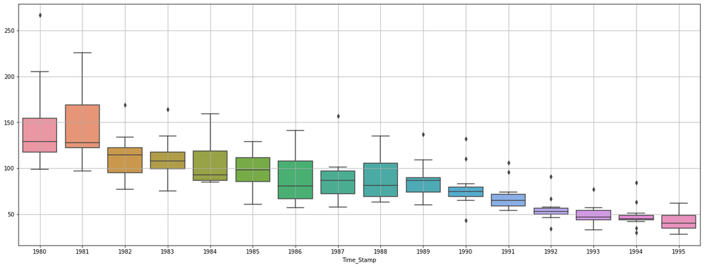

```python
_, ax = plt.subplots(figsize=(22,8))
sns.boxplot(x = df.index.year,y = df.values[:,0],ax=ax)
plt.grid();
```

### Monthly Boxplot:

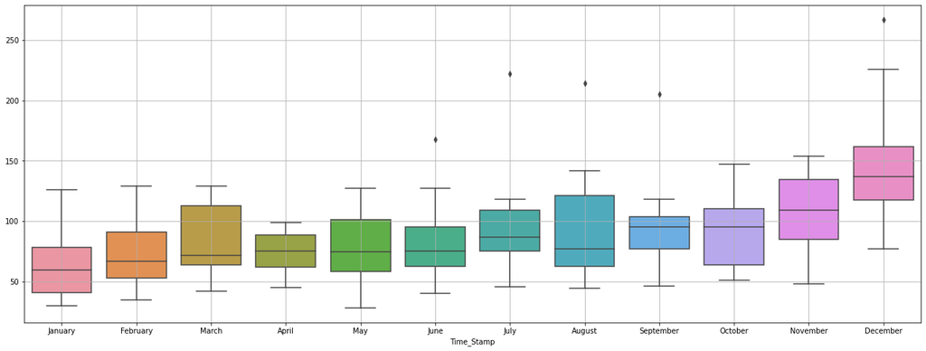

```python
_, ax = plt.subplots(figsize=(22,8))
sns.boxplot(x = df.index.month_name(),y = df.values[:,0],ax=ax)
plt.grid();
```

### Plot a graph of monthly sales across years:

```python
monthly_sales_across_years = pd.pivot_table(df, values = 'Rose', columns = df.index.month_name(), index = df.index.year)
monthly_sales_across_years
```

| Time_Stamp | April | August | December | February | January | July | June | March | May | November | October | September |
| --- | --- | --- | --- | --- | --- | --- | --- | --- | --- | --- | --- | --- |
| 1980 | 99.0 | 129.000000 | 267.0 | 118.0 | 112.0 | 118.000000 | 168.0 | 129.0 | 116.0 | 150.0 | 147.0 | 205.0 |
| 1981 | 97.0 | 214.000000 | 226.0 | 129.0 | 126.0 | 222.000000 | 127.0 | 124.0 | 102.0 | 154.0 | 141.0 | 118.0 |
| 1982 | 97.0 | 117.000000 | 169.0 | 77.0 | 89.0 | 117.000000 | 121.0 | 82.0 | 127.0 | 134.0 | 112.0 | 106.0 |
| 1983 | 85.0 | 124.000000 | 164.0 | 108.0 | 75.0 | 109.000000 | 108.0 | 115.0 | 101.0 | 135.0 | 95.0 | 105.0 |
| 1984 | 87.0 | 142.000000 | 159.0 | 85.0 | 88.0 | 87.000000 | 87.0 | 112.0 | 91.0 | 139.0 | 108.0 | 95.0 |
| 1985 | 93.0 | 103.000000 | 129.0 | 82.0 | 61.0 | 87.000000 | 75.0 | 124.0 | 108.0 | 123.0 | 108.0 | 90.0 |
| 1986 | 71.0 | 118.000000 | 141.0 | 65.0 | 57.0 | 110.000000 | 67.0 | 67.0 | 76.0 | 107.0 | 85.0 | 99.0 |
| 1987 | 86.0 | 73.000000 | 157.0 | 65.0 | 58.0 | 87.000000 | 74.0 | 70.0 | 93.0 | 96.0 | 100.0 | 101.0 |
| 1988 | 66.0 | 77.000000 | 135.0 | 115.0 | 63.0 | 79.000000 | 83.0 | 70.0 | 67.0 | 100.0 | 116.0 | 102.0 |
| 1989 | 74.0 | 74.000000 | 137.0 | 60.0 | 71.0 | 86.000000 | 91.0 | 89.0 | 73.0 | 109.0 | 87.0 | 87.0 |
| 1990 | 77.0 | 70.000000 | 132.0 | 69.0 | 43.0 | 78.000000 | 76.0 | 73.0 | 69.0 | 110.0 | 65.0 | 83.0 |
| 1991 | 65.0 | 55.000000 | 106.0 | 55.0 | 54.0 | 96.000000 | 65.0 | 66.0 | 60.0 | 74.0 | 63.0 | 71.0 |
| 1992 | 53.0 | 52.000000 | 91.0 | 47.0 | 34.0 | 67.000000 | 55.0 | 56.0 | 53.0 | 58.0 | 51.0 | 46.0 |
| 1993 | 45.0 | 54.000000 | 77.0 | 40.0 | 33.0 | 57.000000 | 55.0 | 46.0 | 41.0 | 48.0 | 52.0 | 46.0 |
| 1994 | 48.0 | 44.635276 | 84.0 | 35.0 | 30.0 | 45.386725 | 45.0 | 42.0 | 44.0 | 63.0 | 51.0 | 46.0 |
| 1995 | 52.0 | NaN | NaN | 39.0 | 30.0 | 62.000000 | 40.0 | 45.0 | 28.0 | NaN | NaN | NaN |

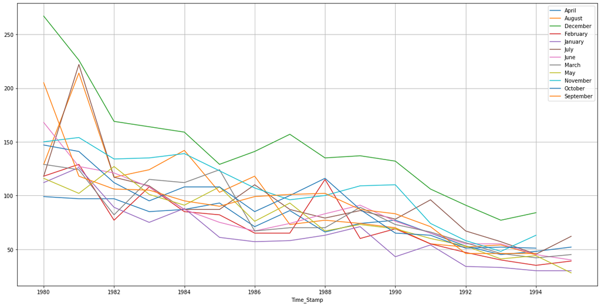

```python
monthly_sales_across_years.plot(figsize=(20,10))
plt.grid()
plt.legend(loc='best');
```

### Decompose the Time Series:

```python
from    statsmodels.tsa.seasonal import   seasonal_decompose
```

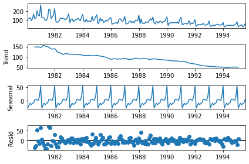

```python
decomposition = seasonal_decompose(df,model='additive')
decomposition.plot();
```

```python
trend = decomposition.trend
seasonality = decomposition.seasonal
residual = decomposition.resid

print('Trend','\n',trend.head(12),'\n')
print('Seasonality','\n',seasonality.head(12),'\n')
print('Residual','\n',residual.head(12),'\n')
```

```
Trend
 Time_Stamp
1980-01-31           NaN
1980-02-29           NaN
1980-03-31           NaN
1980-04-30           NaN
1980-05-31           NaN
1980-06-30           NaN
1980-07-31    147.083333
1980-08-31    148.125000
1980-09-30    148.375000
1980-10-31    148.083333
1980-11-30    147.416667
1980-12-31    145.125000
Name: trend, dtype: float64

Seasonality
 Time_Stamp
1980-01-31   -27.903120
1980-02-29   -17.432786
1980-03-31    -9.279915
1980-04-30   -15.092415
1980-05-31   -10.190629
1980-06-30    -7.672772
1980-07-31     4.905995
1980-08-31     5.436454
1980-09-30     2.780213
1980-10-31     1.877435
1980-11-30    16.852435
1980-12-31    55.719102
Name: seasonal, dtype: float64

Residual
 Time_Stamp
1980-01-31          NaN
1980-02-29          NaN
1980-03-31          NaN
1980-04-30          NaN
1980-05-31          NaN
1980-06-30          NaN
1980-07-31   -33.989328
1980-08-31   -24.561454
1980-09-30    53.844787
1980-10-31    -2.960769
1980-11-30   -14.269102
1980-12-31    66.155898
Name: resid, dtype: float64
```

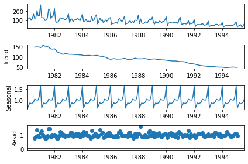

```python
decomposition = seasonal_decompose(df,model='multiplicative')
decomposition.plot();
```

```python
trend = decomposition.trend
seasonality = decomposition.seasonal
residual = decomposition.resid

print('Trend','\n',trend.head(12),'\n')
print('Seasonality','\n',seasonality.head(12),'\n')
print('Residual','\n',residual.head(12),'\n')
```

```
Trend
 Time_Stamp
1980-01-31           NaN
1980-02-29           NaN
1980-03-31           NaN
1980-04-30           NaN
1980-05-31           NaN
1980-06-30           NaN
1980-07-31    147.083333
1980-08-31    148.125000
1980-09-30    148.375000
1980-10-31    148.083333
1980-11-30    147.416667
1980-12-31    145.125000
Name: trend, dtype: float64

Seasonality
 Time_Stamp
1980-01-31    0.670181
1980-02-29    0.806206
1980-03-31    0.901276
1980-04-30    0.854153
1980-05-31    0.889530
1980-06-30    0.924098
1980-07-31    1.058216
1980-08-31    1.034562
1980-09-30    1.017752
1980-10-31    1.022687
1980-11-30    1.192492
1980-12-31    1.628845
Name: seasonal, dtype: float64

Residual
 Time_Stamp
1980-01-31         NaN
1980-02-29         NaN
1980-03-31         NaN
1980-04-30         NaN
1980-05-31         NaN
1980-06-30         NaN
1980-07-31    0.758131
1980-08-31    0.841792
1980-09-30    1.357535
1980-10-31    0.970663
1980-11-30    0.853275
1980-12-31    1.129508
Name: resid, dtype: float64
```

## 3. Split the data into training and test. The test data should start in 1991.

```python
train=df[df.index.year < 1991]
test=df[df.index.year >= 1991]
```

```python
print(train.shape)
print(test.shape)
```

```
(132, 1)
(55, 1)
```

```python
## This is to display multiple data frames from one cell
from IPython.display import display
```

```python
print('First few rows of Training Data')
display(train.head())
print('Last few rows of Training Data')
display(train.tail())
print('First few rows of Test Data')
display(test.head())
print('Last few rows of Test Data')
display(test.tail())
```

```
First few rows of Training Data
```

| Time_Stamp | Rose |
| --- | --- |
| 1980-01-31 | 112.0 |
| 1980-02-29 | 118.0 |
| 1980-03-31 | 129.0 |
| 1980-04-30 | 99.0 |
| 1980-05-31 | 116.0 |

```
Last few rows of Training Data
```

| Time_Stamp | Rose |
| --- | --- |
| 1990-08-31 | 70.0 |
| 1990-09-30 | 83.0 |
| 1990-10-31 | 65.0 |
| 1990-11-30 | 110.0 |
| 1990-12-31 | 132.0 |

```
First few rows of Test Data
```

| Time_Stamp | Rose |
| --- | --- |
| 1991-01-31 | 54.0 |
| 1991-02-28 | 55.0 |
| 1991-03-31 | 66.0 |
| 1991-04-30 | 65.0 |
| 1991-05-31 | 60.0 |

```
Last few rows of Test Data
```

| Time_Stamp | Rose |
| --- | --- |
| 1995-03-31 | 45.0 |
| 1995-04-30 | 52.0 |
| 1995-05-31 | 28.0 |
| 1995-06-30 | 40.0 |
| 1995-07-31 | 62.0 |

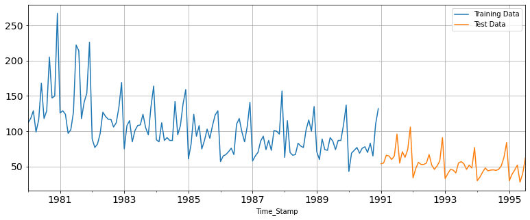

```python
train['Rose'].plot(figsize=(13,5), fontsize=14)
test['Rose'].plot(figsize=(13,5), fontsize=14)
plt.grid()
plt.legend(['Training Data','Test Data'])
plt.show()
```

## 4. Build various exponential smoothing models on the training data and evaluate the model using RMSE on the test data

For this particular linear regression, we are going to regress the 'Sales' variable against the order of the occurrence. For this we need to modify our training data before fitting it into a linear regression

### Building different models and comparing the accuracy metrics.

#### Model 1: Linear Regression

```python
train_time = [i+1 for i in range(len(train))]
test_time = [i+133 for i in range(len(test))]
print('Training Time instance','\n',train_time)
print('Test Time instance','\n',test_time)
```

```
Training Time instance
 [1, 2, 3, 4, 5, 6, 7, 8, 9, 10, 11, 12, 13, 14, 15, 16, 17, 18, 19, 20, 21, 22, 23, 24, 25, 26, 27, 28, 29, 30, 31, 32, 33, 34, 35, 36, 37, 38, 39, 40, 41, 42, 43, 44, 45, 46, 47, 48, 49, 50, 51, 52, 53, 54, 55, 56, 57, 58, 59, 60, 61, 62, 63, 64, 65, 66, 67, 68, 69, 70, 71, 72, 73, 74, 75, 76, 77,…
Test Time instance
 [133, 134, 135, 136, 137, 138, 139, 140, 141, 142, 143, 144, 145, 146, 147, 148, 149, 150, 151, 152, 153, 154, 155, 156, 157, 158, 159, 160, 161, 162, 163, 164, 165, 166, 167, 168, 169, 170, 171, 172, 173, 174, 175, 176, 177, 178, 179, 180, 181, 182, 183, 184, 185, 186, 187]
```

We see that we have successfully the generated the numerical time instance order for both the training and test set. Now we will add these values in the training and test set

```python
LinearRegression_train = train.copy()
LinearRegression_test = test.copy()
```

```python
LinearRegression_train['time'] = train_time
LinearRegression_test['time'] = test_time
```

```python
print('First few rows of Training Data')
display(LinearRegression_train.head())
print('Last few rows of Training Data')
display(LinearRegression_train.tail())
print('First few rows of Test Data')
display(LinearRegression_test.head())
print('Last few rows of Test Data')
display(LinearRegression_test.tail())
```

```
First few rows of Training Data
```

| Time_Stamp | Rose | time |
| --- | --- | --- |
| 1980-01-31 | 112.0 | 1 |
| 1980-02-29 | 118.0 | 2 |
| 1980-03-31 | 129.0 | 3 |
| 1980-04-30 | 99.0 | 4 |
| 1980-05-31 | 116.0 | 5 |

```
Last few rows of Training Data
```

| Time_Stamp | Rose | time |
| --- | --- | --- |
| 1990-08-31 | 70.0 | 128 |
| 1990-09-30 | 83.0 | 129 |
| 1990-10-31 | 65.0 | 130 |
| 1990-11-30 | 110.0 | 131 |
| 1990-12-31 | 132.0 | 132 |

```
First few rows of Test Data
```

| Time_Stamp | Rose | time |
| --- | --- | --- |
| 1991-01-31 | 54.0 | 133 |
| 1991-02-28 | 55.0 | 134 |
| 1991-03-31 | 66.0 | 135 |
| 1991-04-30 | 65.0 | 136 |
| 1991-05-31 | 60.0 | 137 |

```
Last few rows of Test Data
```

| Time_Stamp | Rose | time |
| --- | --- | --- |
| 1995-03-31 | 45.0 | 183 |
| 1995-04-30 | 52.0 | 184 |
| 1995-05-31 | 28.0 | 185 |
| 1995-06-30 | 40.0 | 186 |
| 1995-07-31 | 62.0 | 187 |

```python
from sklearn.linear_model import LinearRegression
```

```python
lr = LinearRegression()
```

```python
lr.fit(LinearRegression_train[['time']],LinearRegression_train['Rose'].values)
```

```
LinearRegression()
```

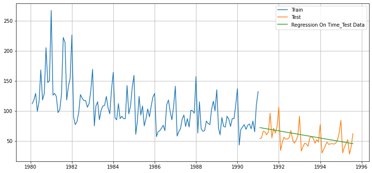

```python
test_predictions_model1         = lr.predict(LinearRegression_test[['time']])
LinearRegression_test['RegOnTime'] = test_predictions_model1

plt.figure(figsize=(13,6))
plt.plot( train['Rose'], label='Train')
plt.plot(test['Rose'], label='Test')
plt.plot(LinearRegression_test['RegOnTime'], label='Regression On Time_Test Data')
plt.legend(loc='best')
plt.grid();
```

### Defining the accuracy metrics

```python
from sklearn import metrics
```

#### Model Evaluation:

```python
## Test Data - RMSE

rmse_model1_test = metrics.mean_squared_error(test['Rose'],test_predictions_model1,squared=False)
print("For RegressionOnTime forecast on the Test Data,  RMSE is %3.3f" %(rmse_model1_test))
```

```
For RegressionOnTime forecast on the Test Data,  RMSE is 15.276
```

```python
resultsDf = pd.DataFrame({'Test RMSE': [rmse_model1_test]},index=['RegressionOnTime'])
resultsDf
```

|  | Test RMSE |
| --- | --- |
| RegressionOnTime | 15.27552 |

## Model 2: Naive Approach

For this particular naive model, we say that the prediction for tomorrow is the same as today and the prediction for day after tomorrow is tomorrow and since the prediction of tomorrow is same as today,therefore the prediction for day after tomorrow is also today.

```python
NaiveModel_train = train.copy()
NaiveModel_test = test.copy()
```

```python
NaiveModel_test['naive'] = np.asarray(train['Rose'])[len(np.asarray(train['Rose']))-1]
NaiveModel_test['naive'].head()
```

```
Time_Stamp
1991-01-31    132.0
1991-02-28    132.0
1991-03-31    132.0
1991-04-30    132.0
1991-05-31    132.0
Name: naive, dtype: float64
```

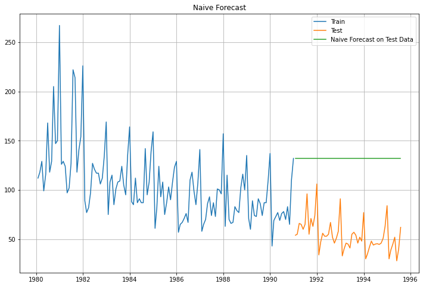

```python
plt.figure(figsize=(12,8))
plt.plot(NaiveModel_train['Rose'], label='Train')
plt.plot(test['Rose'], label='Test')
plt.plot(NaiveModel_test['naive'], label='Naive Forecast on Test Data')
plt.legend(loc='best')
plt.title("Naive Forecast")
plt.grid();
```

#### Model Evaluation:

```python
## Test Data - RMSE

rmse_model2_test = metrics.mean_squared_error(test['Rose'],NaiveModel_test['naive'],squared=False)
print("For RegressionOnTime forecast on the Test Data,  RMSE is %3.3f" %(rmse_model2_test))
```

[output not shown]

```python
resultsDf_2 = pd.DataFrame({'Test RMSE': [rmse_model2_test]},index=['NaiveModel'])

resultsDf = pd.concat([resultsDf, resultsDf_2])
resultsDf
```

|  | Test RMSE |
| --- | --- |
| RegressionOnTime | 15.275520 |
| NaiveModel | 79.738146 |

## Method 3: Simple Average

For this particular simple average method, we will forecast by using the average of the training values.

```python
SimpleAverage_train = train.copy()
SimpleAverage_test = test.copy()
```

```python
SimpleAverage_test['mean_forecast'] = train['Rose'].mean()
SimpleAverage_test.head()
```

| Time_Stamp | Rose | mean_forecast |
| --- | --- | --- |
| 1991-01-31 | 54.0 | 104.939394 |
| 1991-02-28 | 55.0 | 104.939394 |
| 1991-03-31 | 66.0 | 104.939394 |
| 1991-04-30 | 65.0 | 104.939394 |
| 1991-05-31 | 60.0 | 104.939394 |

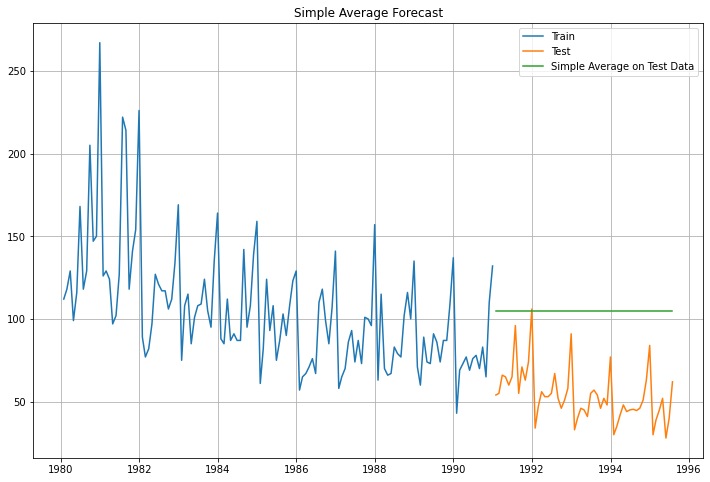

```python
plt.figure(figsize=(12,8))
plt.plot(SimpleAverage_train['Rose'], label='Train')
plt.plot(SimpleAverage_test['Rose'], label='Test')
plt.plot(SimpleAverage_test['mean_forecast'], label='Simple Average on Test Data')
plt.legend(loc='best')
plt.title("Simple Average Forecast")
plt.grid();
```

### Model Evaluation:

```python
## Test Data - RMSE

rmse_model3_test = metrics.mean_squared_error(test['Rose'],SimpleAverage_test['mean_forecast'],squared=False)
print("For Simple Average forecast on the Test Data,  RMSE is %3.3f" %(rmse_model3_test))
```

```
For Simple Average forecast on the Test Data,  RMSE is 53.480
```

```python
resultsDf_3 = pd.DataFrame({'Test RMSE': [rmse_model3_test]},index=['SimpleAverageModel'])

resultsDf = pd.concat([resultsDf, resultsDf_3])
resultsDf
```

|  | Test RMSE |
| --- | --- |
| RegressionOnTime | 15.275520 |
| NaiveModel | 79.738146 |
| SimpleAverageModel | 53.480456 |

## Method 4: Moving Average(MA)

Moving Average, we are going to average over the entire data.

```python
MovingAverage = df.copy()
MovingAverage.head()
```

| Time_Stamp | Rose |
| --- | --- |
| 1980-01-31 | 112.0 |
| 1980-02-29 | 118.0 |
| 1980-03-31 | 129.0 |
| 1980-04-30 | 99.0 |
| 1980-05-31 | 116.0 |

```python
MovingAverage['Trailing_2'] = MovingAverage['Rose'].rolling(2).mean()
MovingAverage['Trailing_4'] = MovingAverage['Rose'].rolling(4).mean()
MovingAverage['Trailing_6'] = MovingAverage['Rose'].rolling(6).mean()
MovingAverage['Trailing_9'] = MovingAverage['Rose'].rolling(9).mean()

MovingAverage.head()
```

| Time_Stamp | Rose | Trailing_2 | Trailing_4 | Trailing_6 | Trailing_9 |
| --- | --- | --- | --- | --- | --- |
| 1980-01-31 | 112.0 | NaN | NaN | NaN | NaN |
| 1980-02-29 | 118.0 | 115.0 | NaN | NaN | NaN |
| 1980-03-31 | 129.0 | 123.5 | NaN | NaN | NaN |
| 1980-04-30 | 99.0 | 114.0 | 114.5 | NaN | NaN |
| 1980-05-31 | 116.0 | 107.5 | 115.5 | NaN | NaN |

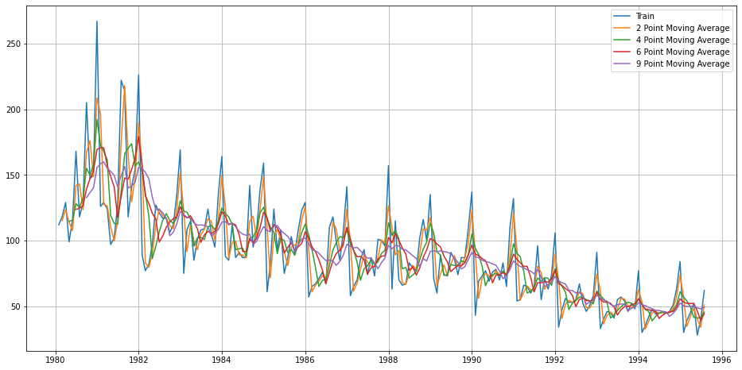

```python
## Plotting on the whole data

plt.figure(figsize=(16,8))
plt.plot(MovingAverage['Rose'], label='Train')
plt.plot(MovingAverage['Trailing_2'], label='2 Point Moving Average')
plt.plot(MovingAverage['Trailing_4'], label='4 Point Moving Average')
plt.plot(MovingAverage['Trailing_6'],label = '6 Point Moving Average')
plt.plot(MovingAverage['Trailing_9'],label = '9 Point Moving Average')

plt.legend(loc = 'best')
plt.grid();
```

Let us split the data into train and test and plot this Time Series. The window of the moving average is need to be carefully selected as too big a window will result in not having any test set as the whole series might get averaged over

```python
#Creating train and test set
trailing_MovingAverage_train=MovingAverage[MovingAverage.index.year < 1991]
trailing_MovingAverage_test=MovingAverage[MovingAverage.index.year >= 1991]
#train=df[df.index.year < 1991]
#test=df[df.index.year >= 1991]
```

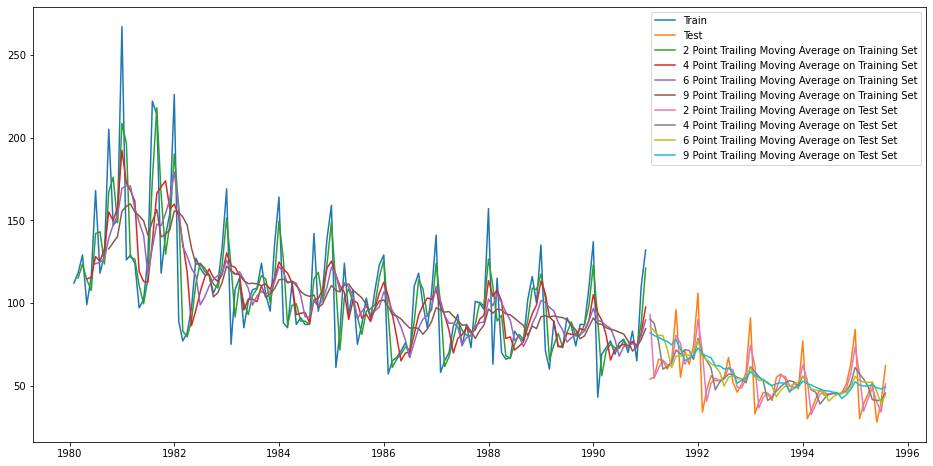

```python
## Plotting on both the Training and Test data

plt.figure(figsize=(16,8))
plt.plot(trailing_MovingAverage_train['Rose'], label='Train')
plt.plot(trailing_MovingAverage_test['Rose'], label='Test')

plt.plot(trailing_MovingAverage_train['Trailing_2'], label='2 Point Trailing Moving Average on Training Set')
plt.plot(trailing_MovingAverage_train['Trailing_4'], label='4 Point Trailing Moving Average on Training Set')
plt.plot(trailing_MovingAverage_train['Trailing_6'],label = '6 Point Trailing Moving Average on Training Set')
plt.plot(trailing_MovingAverage_train['Trailing_9'],label = '9 Point Trailing Moving Average on Training Set')

plt.plot(trailing_MovingAverage_test['Trailing_2'], label='2 Point Trailing Moving Average on Test Set')
plt.plot(trailing_MovingAverage_test['Trailing_4'], label='4 Point Trailing Moving Average on Test Set')
plt.plot(trailing_MovingAverage_test['Trailing_6'],label = '6 Point Trailing Moving Average on Test Set')
plt.plot(trailing_MovingAverage_test['Trailing_9'],label = '9 Point Trailing Moving Average on Test Set')
plt.legend(loc = 'best')
```